# Practical Machine Learning Predcition Assignment

Kinga F.

Sunday, January 25, 2015

## Getting the Data

The data source for this project is from: http://groupware.les.inf.puc-rio.br/har.

Reading in the training dataset that was downloaded from https://d396qusza40orc.cloudfront.net/predmachlearn/pml-training.csv:

```r
training <- read.csv("pml-training.csv")
attach(training) #attaching data frame to reduce the length of the variable names associated to it.
```

Reading is the test set that has been downloaded from https://d396qusza40orc.cloudfront.net/predmachlearn/pml-testing.csv:

```r
testing <- read.csv("pml-testing.csv")
```

## Exploring the Data

```r
tail(names(training),24)
```

```
##  [1] "amplitude_roll_forearm"  "amplitude_pitch_forearm"
##  [3] "amplitude_yaw_forearm"   "total_accel_forearm"
##  [5] "var_accel_forearm"       "avg_roll_forearm"
##  [7] "stddev_roll_forearm"     "var_roll_forearm"
##  [9] "avg_pitch_forearm"       "stddev_pitch_forearm"
## [11] "var_pitch_forearm"       "avg_yaw_forearm"
## [13] "stddev_yaw_forearm"      "var_yaw_forearm"
## [15] "gyros_forearm_x"         "gyros_forearm_y"
## [17] "gyros_forearm_z"         "accel_forearm_x"
## [19] "accel_forearm_y"         "accel_forearm_z"
## [21] "magnet_forearm_x"        "magnet_forearm_y"
## [23] "magnet_forearm_z"        "classe"
```

The response variable is “classe” and the rest of the variables are all potential predictors of this response variable. To get an idea of the size of this dataset, here are some basic numbers:

```
    - the number of variables is 160

    - the number of observations in this dataset is 19622
```

In order to have some idea of what the response variable looks like, here is the summary of it:

```r
summary(training$classe)
```

```
##    A    B    C    D    E
## 5580 3797 3422 3216 3607
```

After some further examination of the dataset, there are a few things I need to note:

```
    1.Some of the values are missing, as in the column "skewness_yaw_belt" and some of the values are "NA", as in the column "max_roll_belt":
```

```r
head(training[,c(16,17,18)])
```

```
##   skewness_roll_belt.1 skewness_yaw_belt max_roll_belt
## 1                                                   NA
## 2                                                   NA
## 3                                                   NA
## 4                                                   NA
## 5                                                   NA
## 6                                                   NA
```

```
    2. Some of the variables are factor variables with over 100 factors:
```

```r
is.factor(kurtosis_roll_belt)
```

```
## [1] TRUE
```

```r
str(kurtosis_roll_belt)
```

```
##  Factor w/ 397 levels "","-0.016850",..: 1 1 1 1 1 1 1 1 1 1 ...
```

## Plotting Predictors

In order to best determine which model to choose to predict “classe”, I chose to graph some of the predictors in a feature plot.

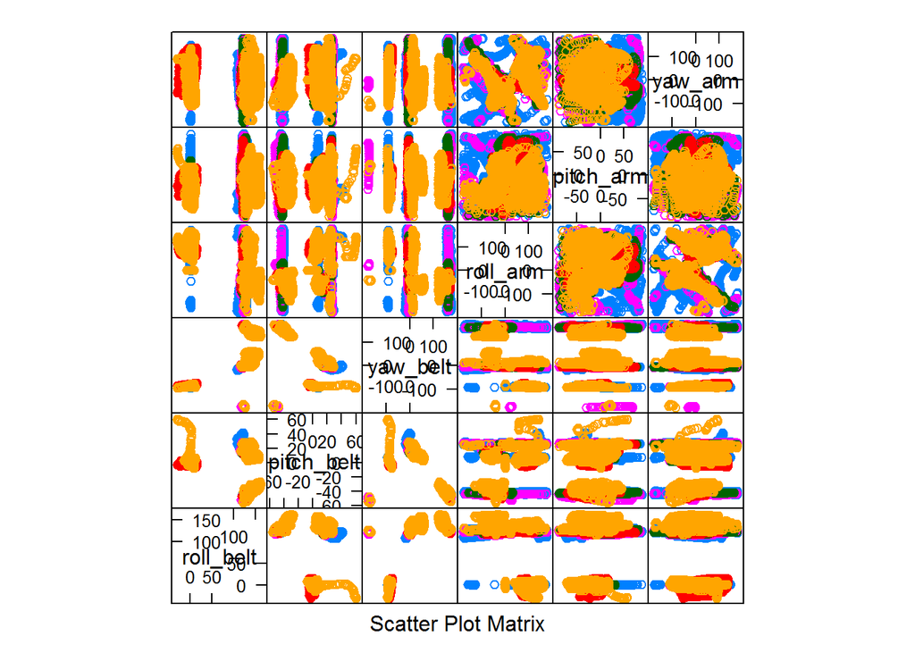

```r
library(ggplot2); library(caret)
#selecting a few of the more promising predictors to be plotted
colSelection<- c("roll_belt","pitch_belt", "yaw_belt", "roll_arm", "pitch_arm",
                 "yaw_arm")

#creating a feature plot
featurePlot(x=training[,colSelection],
           y = training$classe,
          plot="pairs")
```

In order to closer examine the feature plot, I plotted many of them separately, here is an example of a close-up:

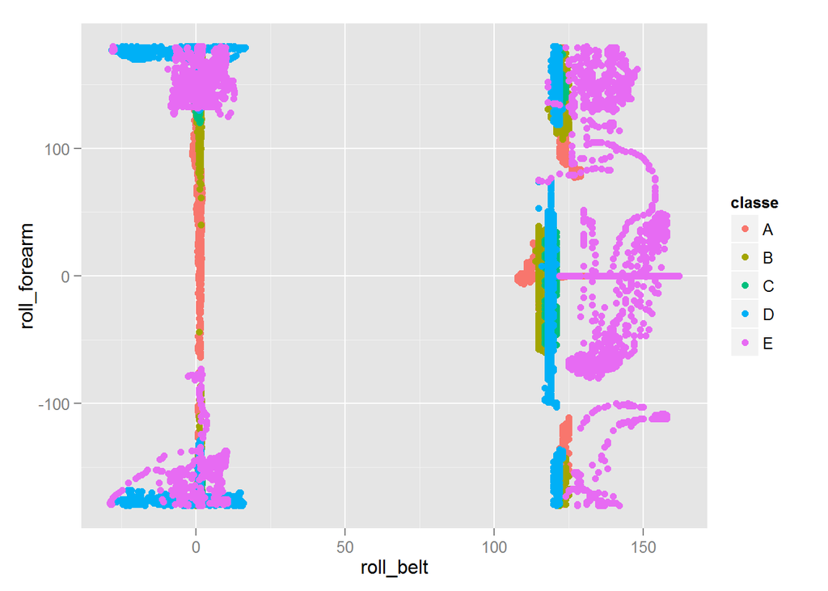

```r
qplot(roll_belt, roll_forearm, colour=classe, data=training)
```

In order to understand what is going with the strange groupings on I created a histogram of “roll_belt” and of “roll_forearm”

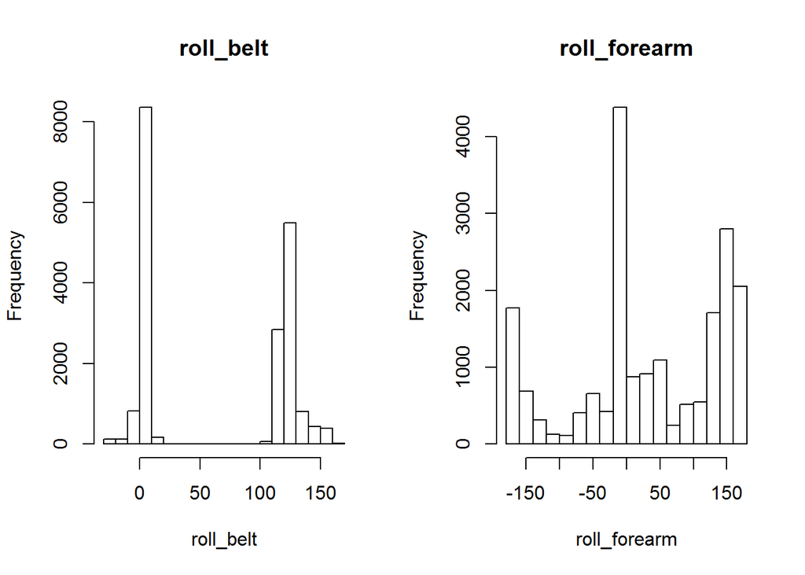

```r
par(mfrow=c(1,2))
hist(roll_belt, main = "roll_belt")
hist(roll_forearm, main="roll_forearm")
```

However, the graphs did not help me understand the data any better, other than to note the absence of a normal distribution. There are simply too many variables to dwell on them individually for too long.

## Preprocessing the Data

The first 7 variables in the training data set are:

X, user_name, raw_timestamp_part_1, raw_timestamp_part_2, cvtd_timestamp, new_window, num_window,

I removed these from the data set since they were not relevant towards predicting “classe”. The removed variables included the time stamp ones as well, since I did not inted to do a time series analysis.

```r
training <- training[,-c(1,2,3,4,5,6,7)]
```

Next, I removed all the columns with missing values from the dataset:

```r
training <-training[,colSums(is.na(training))==0]
```

Then, I found all the columns that are factors, while ignoring the last column which was the response variable “classe.”

```r
col_names <- c()
n <- ncol(training)-1
for (i in 1:n) {
     if (is.factor(training[,i])){
             col_names <- c(col_names,i)
           }
}
```

I then removed these columns from the data frame, since some of the machine learning algorithms cannot work with factor variables that have over 32 levels.

```r
training <- training[,-col_names]
```

Overall, I have reduced the number of predictive variables from 159 to 52.

## Cross Validation Using Random Subsampling and Random Forest

I used a for loop to set up cross validation using random subsampling to fit three random forest models to random subsets of the training data, called “trainingSet”. I then used these models to predict the “classe” variable of the testing subsets, called “testingSet”. I was hoping for an out of sample error of less than 20%.

```r
library(randomForest)
first_seed <- 123355
accuracies <-c()
for (i in 1:3){
       set.seed(first_seed)
       first_seed <- first_seed+1
       trainIndex <- createDataPartition(y=training$classe, p=0.75, list=FALSE)
       trainingSet<- training[trainIndex,]
       testingSet<- training[-trainIndex,]
       modelFit <- randomForest(classe ~., data = trainingSet)
       prediction <- predict(modelFit, testingSet)
       testingSet$rightPred <- prediction == testingSet$classe
       t<-table(prediction, testingSet$classe)
       print(t)
       accuracy <- sum(testingSet$rightPred)/nrow(testingSet)
       accuracies <- c(accuracies,accuracy)
       print(accuracy)
}
```

```
##
## prediction    A    B    C    D    E
##          A 1392    2    0    0    0
##          B    0  946    8    0    0
##          C    0    1  847    7    0
##          D    0    0    0  796    4
##          E    3    0    0    1  897
## [1] 0.9946982
##
## prediction    A    B    C    D    E
##          A 1395    6    0    0    0
##          B    0  936    6    0    0
##          C    0    7  849    4    1
##          D    0    0    0  796    1
##          E    0    0    0    4  899
## [1] 0.9940865
##
## prediction    A    B    C    D    E
##          A 1394    1    0    0    0
##          B    1  947    5    0    0
##          C    0    1  849   10    0
##          D    0    0    1  793    4
##          E    0    0    0    1  897
## [1] 0.995106
```

```r
accuracies
```

```
## [1] 0.9946982 0.9940865 0.9951060
```

```r
mean(accuracies)
```

```
## [1] 0.9946302
```

## Applying the Random Forest Model to the 20 Test Cases

I fit a random forest model to the entire training data set this time, and I used the model to predict the “classe” variable for the 20 test cases in the testing data set.

```r
modelFit <- randomForest(classe ~., data = training)
nrow(testing)
```

```
## [1] 20
```

```r
prediction <- predict(modelFit, testing)
prediction
```

```
##  1  2  3  4  5  6  7  8  9 10 11 12 13 14 15 16 17 18 19 20
##  B  A  B  A  A  E  D  B  A  A  B  C  B  A  E  E  A  B  B  B
## Levels: A B C D E
```